# Harmonized Drug Dataset Quality Control

James Bannon, Michael Tran

July 30, 2026

# 1 Overview

This report is a quality control walkthrough for the lab-generated Harmonized Drug Dataset stored as a `MultiAssayExperiment` (MAE). The dataset harmonizes multiple drug-related assays and features across a shared compound universe keyed by `HDD.Compound.ID` so downstream analyses can operate on a consistent sample space. `Pubchem.CID` is retained when available, but it is not required for a compound to be included.

## 1.1 Data Sources

The MAE is constructed in `workflow/scripts/construct_MAE.R`. It pulls processed experiments from `data/procdata/experiments/` and a `colData` table from `data/procdata/colData.csv`. Key sources (from `config/pipeline.yaml` and the workflow scripts) include:

- **DeepChem datasets** (Tox21, ToxCast, SIDER, ClinTox): downloaded from DeepChem S3, then re-shaped to `HDD.Compound.ID`-by-assay matrices.
- **JUMP-CP** membership and source identifiers from the curated cpg0016 MAE.
- **OASIS** membership and source identifiers from the curated cpg0037 MAE.
- **GEOM** membership and source identifiers from the curated GEOM MAE.
- **LINCS** membership and source identifiers from the curated LINCS MAE.
- **CTRPv2** membership and master compound identifiers from the CTRPv2 PharmacoSet.
- **NCI60** membership and NSC identifiers from the NCI60-2026 PharmacoSet.
- **Bioassays**: pulled from AnnotationDB alongside compound metadata, with bioassays filtered to gold-standard assays.
- **ATC codes**: pulled from AnnotationDB when an authorization key is available.
- **LTKB**: DILI labels pulled from AnnotationDB for the LTKB Benchmark Dataset, DILIrank, and DILIst label sets.
- **LiverTox**: hepatotoxicity likelihood score and reason pulled from AnnotationDB.
- **DIRIL and DICT**: renal and cardiac toxicity labels pulled from AnnotationDB.
- **Fingerprints**: RDKit Morgan count fingerprints generated for compounds with parseable SMILES.

# 2 Load HDD

```r
suppressPackageStartupMessages({
  library(MultiAssayExperiment)
  library(SummarizedExperiment)
  library(Matrix)
  library(ggplot2)
  library(dplyr)
  library(tidyr)
})

hdd_mae <- readRDS("data/results/HDD_v2.3.RDS")
hdd_mae
```

```
## A MultiAssayExperiment object of 9 listed
##  experiments with user-defined names and respective classes.
##  Containing an ExperimentList class object of length 9:
##  [1] SIDER: SummarizedExperiment with 27 rows and 1396 columns
##  [2] Bioassays: SummarizedExperiment with 42 rows and 438498 columns
##  [3] Tox21: SummarizedExperiment with 12 rows and 5944 columns
##  [4] ToxCast: SummarizedExperiment with 617 rows and 6694 columns
##  [5] ClinTox: SummarizedExperiment with 2 rows and 924 columns
##  [6] fingerprint.Morgan.2.1024: SummarizedExperiment with 1024 rows and 646039 columns
##  [7] fingerprint.Morgan.2.2048: SummarizedExperiment with 2048 rows and 646039 columns
##  [8] fingerprint.Morgan.3.1024: SummarizedExperiment with 1024 rows and 646039 columns
##  [9] fingerprint.Morgan.3.2048: SummarizedExperiment with 2048 rows and 646039 columns
## Functionality:
##  experiments() - obtain the ExperimentList instance
##  colData() - the primary/phenotype DataFrame
##  sampleMap() - the sample coordination DataFrame
##  `$`, `[`, `[[` - extract colData columns, subset, or experiment
##  *Format() - convert into a long or wide DataFrame
##  assays() - convert ExperimentList to a SimpleList of matrices
##  exportClass() - save data to flat files
```

```r
format_file_size <- function(bytes) {
  if (is.na(bytes)) {
    return(NA_character_)
  }

  units <- c("B", "KB", "MB", "GB")
  unit_idx <- 1
  value <- bytes
  while (value >= 1024 && unit_idx < length(units)) {
    value <- value / 1024
    unit_idx <- unit_idx + 1
  }

  sprintf("%.1f %s", value, units[[unit_idx]])
}

expected_outputs <- c(
  "data/results/HDD_v2.3.RDS",
  "data/results/HDD_v2.3_csv",
  "data/results/HDD_v2.3_csv.tar.gz"
)

output_summary <- tibble::tibble(
  path = expected_outputs,
  exists = file.exists(expected_outputs),
  size = vapply(
    expected_outputs,
    function(path) {
      if (file.exists(path) && !dir.exists(path)) {
        file.info(path)$size
      } else if (dir.exists(path)) {
        sum(
          file.info(list.files(path, recursive = TRUE, full.names = TRUE))$size,
          na.rm = TRUE
        )
      } else {
        NA_real_
      }
    },
    numeric(1)
  ),
  size_pretty = vapply(size, format_file_size, character(1)),
  modified = as.POSIXct(
    vapply(
      expected_outputs,
      function(path) {
        if (file.exists(path)) {
          file.info(path)$mtime
        } else {
          NA
        }
      },
      as.POSIXct(NA)
    ),
    origin = "1970-01-01"
  )
)

output_summary
```

| path | exists | size | size_pretty | modified |
| --- | --- | --- | --- | --- |
| data/results/HDD_v2.3.RDS | TRUE | 4.83e+08 | 460.5 MB | 2026-07-30 14:28:32.289 |
| data/results/HDD_v2.3_csv | TRUE | 8.48e+09 | 7.9 GB | 2026-07-30 14:34:00.623 |
| data/results/HDD_v2.3_csv.tar.gz | FALSE | NA | NA |  |

```r
compound_labels <- as.data.frame(colData(hdd_mae)) |>
  tibble::rownames_to_column("sample_id") |>
  transmute(
    sample_id = as.character(sample_id),
    compound_label = dplyr::coalesce(
      na_if(trimws(as.character(Molecule.Name)), ""),
      na_if(trimws(as.character(IUPAC.Name)), ""),
      na_if(trimws(as.character(Pubchem.CID)), ""),
      na_if(trimws(as.character(HDD.Compound.ID)), ""),
      sample_id
    )
  )

compound_labels$compound_label <- make.unique(compound_labels$compound_label)
```

# 3 MAE snapshot

```r
experiment_names <- names(experiments(hdd_mae))
experiment_names
```

```
## [1] "SIDER"                     "Bioassays"
## [3] "Tox21"                     "ToxCast"
## [5] "ClinTox"                   "fingerprint.Morgan.2.1024"
## [7] "fingerprint.Morgan.2.2048" "fingerprint.Morgan.3.1024"
## [9] "fingerprint.Morgan.3.2048"
```

```r
has_experiment <- function(name) {
  name %in% experiment_names
}

assay_missing_fraction <- function(assay_obj) {
  dims <- dim(assay_obj)
  total_values <- prod(dims)

  if (inherits(assay_obj, "sparseMatrix")) {
    stored_values <- if ("x" %in% slotNames(assay_obj)) {
      slot(assay_obj, "x")
    } else {
      NULL
    }

    if (length(stored_values) == 0) {
      return(0)
    }
    return(sum(is.na(stored_values)) / total_values)
  }

  mean(is.na(assay_obj))
}

summarize_experiment <- function(se) {
  assay_obj <- assays(se)[[1]]
  data_class <- class(assay_obj)[1]
  dims <- dim(assay_obj)
  missing_fraction <- assay_missing_fraction(assay_obj)

  data.frame(
    assay_name = assayNames(se)[1],
    rows = dims[1],
    cols = dims[2],
    data_class = data_class,
    missing_fraction = missing_fraction,
    stringsAsFactors = FALSE
  )
}

experiment_summary <- do.call(
  rbind,
  lapply(experiments(hdd_mae), summarize_experiment)
)
rownames(experiment_summary) <- experiment_names
experiment_summary
```

|  | assay_name | rows | cols | data_class | missing_fraction |
| --- | --- | --- | --- | --- | --- |
| SIDER | SIDER | 27 | 1396 | matrix | 0.000 |
| Bioassays | Bioassays | 42 | 438498 | data.frame | 0.969 |
| Tox21 | Tox21 | 12 | 5944 | data.frame | 0.168 |
| ToxCast | ToxCast | 617 | 6694 | data.frame | 0.705 |
| ClinTox | ClinTox | 2 | 924 | data.frame | 0.000 |
| fingerprint.Morgan.2.1024 | fp.name | 1024 | 646039 | dgCMatrix | 0.000 |
| fingerprint.Morgan.2.2048 | fp.name | 2048 | 646039 | dgCMatrix | 0.000 |
| fingerprint.Morgan.3.1024 | fp.name | 1024 | 646039 | dgCMatrix | 0.000 |
| fingerprint.Morgan.3.2048 | fp.name | 2048 | 646039 | dgCMatrix | 0.000 |

Basic sanity checks for sampleMap completeness and the HDD schema.

```r
# Basic sampleMap sanity checks
all_in_coldata <- lapply(experiments(hdd_mae), function(se) {
  all(colnames(se) %in% rownames(colData(hdd_mae)))
})
if (all(unlist(all_in_coldata))) {
  print("All experiments map cleanly to colData.")
} else {
  print("Some experiments contain samples missing from colData:")
  print(all_in_coldata[!unlist(all_in_coldata)])
}
```

```
## [1] "All experiments map cleanly to colData."
```

```r
# Any missing samples per experiment (only report issues)
missing_samples <- lapply(experiments(hdd_mae), function(se) {
  setdiff(colnames(se), rownames(colData(hdd_mae)))
})
missing_samples <- missing_samples[lengths(missing_samples) > 0]
if (length(missing_samples) == 0) {
  print("No missing samples detected in any experiment.")
} else {
  print("Missing samples by experiment:")
  print(missing_samples)
}
```

```
## [1] "No missing samples detected in any experiment."
```

```r
schema_checks <- tibble::tibble(
  check = c(
    "LINCS membership present",
    "JUMP-CP membership present",
    "OASIS membership present",
    "GEOM membership present",
    "CTRP membership present",
    "NCI60 membership present",
    "HDD compound ID present"
  ),
  passed = c(
    "In.LINCS" %in% colnames(colData(hdd_mae)),
    "In.JUMP.CP" %in% colnames(colData(hdd_mae)),
    "In.OASIS" %in% colnames(colData(hdd_mae)),
    "In.GEOM" %in% colnames(colData(hdd_mae)),
    "In.CTRP" %in% colnames(colData(hdd_mae)),
    "In.NCI60" %in% colnames(colData(hdd_mae)),
    "HDD.Compound.ID" %in% colnames(colData(hdd_mae))
  )
)
schema_checks
```

| check | passed |
| --- | --- |
| LINCS membership present | TRUE |
| JUMP-CP membership present | TRUE |
| OASIS membership present | TRUE |
| GEOM membership present | TRUE |
| CTRP membership present | TRUE |
| NCI60 membership present | TRUE |
| HDD compound ID present | TRUE |

```r
stopifnot(all(schema_checks$passed))

source_membership_counts <- tibble::tibble(
  source = c("LINCS", "JUMP-CP", "OASIS", "GEOM", "CTRPv2", "NCI60"),
  flag_column = c(
    "In.LINCS",
    "In.JUMP.CP",
    "In.OASIS",
    "In.GEOM",
    "In.CTRP",
    "In.NCI60"
  )
) |>
  mutate(
    compound_count = vapply(
      flag_column,
      function(column) {
        sum(as.logical(colData(hdd_mae)[[column]]), na.rm = TRUE)
      },
      integer(1)
    )
  )

source_membership_counts
```

| source | flag_column | compound_count |
| --- | --- | --- |
| LINCS | In.LINCS | 20785 |
| JUMP-CP | In.JUMP.CP | 115730 |
| OASIS | In.OASIS | 1086 |
| GEOM | In.GEOM | 301536 |
| CTRPv2 | In.CTRP | 545 |
| NCI60 | In.NCI60 | 134716 |

```r
samplemap_coverage <- tibble::tibble(
  colData_rows = nrow(colData(hdd_mae)),
  sampleMap_primary_ids = dplyr::n_distinct(sampleMap(hdd_mae)$primary),
  colData_rows_absent_from_sampleMap = sum(
    !rownames(colData(hdd_mae)) %in% sampleMap(hdd_mae)$primary
  )
)
samplemap_coverage
```

| colData_rows | sampleMap_primary_ids | colData_rows_absent_from_sampleMap |
| --- | --- | --- |
| 648122 | 646039 | 2083 |

# 4 colData overview

```r
cd <- colData(hdd_mae)
cd[1:5, 1:min(10, ncol(cd))]
```

```
## DataFrame with 5 rows and 10 columns
##                   HDD.Compound.ID Pubchem.CID               InChIKey
##                       <character>   <integer>            <character>
## HDD_100Qq7ZWzc84 HDD_100Qq7ZWzc84    59242746 IHIWYQYVBNODSV-UHFFF..
## HDD_100VcBf7xNmF HDD_100VcBf7xNmF    45028681                     NA
## HDD_100qxkzFVw1Y HDD_100qxkzFVw1Y       77907 CPLJMYOQYRCCBY-UHFFF..
## HDD_101gEGLkpWU6 HDD_101gEGLkpWU6   172408060                     NA
## HDD_101w9WD4OfLl HDD_101w9WD4OfLl    45029002                     NA
##                                    SMILES          Molecule.Name
##                               <character>            <character>
## HDD_100Qq7ZWzc84   CC(C)OC(=O)NC1CC2=C(.. (+/-)-(7-Cyano-4-pyr..
## HDD_100VcBf7xNmF  COc1ccc2O\\C(=C/c3ccc..                 743693
## HDD_100qxkzFVw1Y             CCCC1=CC=CO1          2-Propylfuran
## HDD_101gEGLkpWU6 Cc1onc(c1)\\N=C\\2/NC(..                 832929
## HDD_101w9WD4OfLl   COc1ccc(cc1)C(=O)COc..                 745180
##                  In.AnnotationDB      AnnotationDB.Name    AnnotationDB.SMILES
##                        <logical>            <character>            <character>
## HDD_100Qq7ZWzc84            TRUE (+/-)-(7-Cyano-4-pyr.. CC(C)OC(=O)NC1CC2=C(..
## HDD_100VcBf7xNmF           FALSE                     NA                     NA
## HDD_100qxkzFVw1Y            TRUE          2-Propylfuran           CCCC1=CC=CO1
## HDD_101gEGLkpWU6           FALSE                     NA                     NA
## HDD_101w9WD4OfLl           FALSE                     NA                     NA
##                  In.JUMP.CP     JUMP.CP.ID
##                   <logical>    <character>
## HDD_100Qq7ZWzc84       TRUE JCP2022_035074
## HDD_100VcBf7xNmF      FALSE             NA
## HDD_100qxkzFVw1Y      FALSE             NA
## HDD_101gEGLkpWU6      FALSE             NA
## HDD_101w9WD4OfLl      FALSE             NA
```

```r
# Quick missingness scan
missing_by_field <- sapply(cd, function(x) {
  mean(is.na(x))
})
missing_by_field
```

```
##                           HDD.Compound.ID
##                                   0.00000
##                               Pubchem.CID
##                                   0.16263
##                                  InChIKey
##                                   0.06762
##                                    SMILES
##                                   0.00151
##                             Molecule.Name
##                                   0.00000
##                           In.AnnotationDB
##                                   0.00000
##                         AnnotationDB.Name
##                                   0.32343
##                       AnnotationDB.SMILES
##                                   0.32343
##                                In.JUMP.CP
##                                   0.00000
##                                JUMP.CP.ID
##                                   0.82144
##                                  In.OASIS
##                                   0.00000
##                                  OASIS.ID
##                                   0.99851
##                                   In.GEOM
##                                   0.00000
##                        GEOM.Source.SMILES
##                                   0.53475
##                                  In.LINCS
##                                   0.00000
##                           LINCS.CMap.Name
##                                   0.96793
##                                   In.CTRP
##                                   0.00000
##                        CTRP.Master.CPD.ID
##                                   0.99916
##                                  In.NCI60
##                                   0.00000
##                                 NCI60.NSC
##                                   0.79214
```

[output cut: 39 more lines]

```
##                                   0.99973
##                           DIRIL.Label.Shi
##                                   0.99961
##                            DIRIL.Toxicity
##                                   0.99951
##                       DICT.Cardiotoxicity
##                                   0.99878
##                        DICT.Label.Section
##                                   0.99815
##                              DICT.Concern
##                                   0.99815
##                             DICT.Keywords
##                                   0.99850
##                             BBB.Permeable
##                                   0.99991
```

```r
# Distinct counts for key identifiers
c(
  n_compounds = nrow(cd),
  unique_hdd_ids = length(unique(cd$HDD.Compound.ID)),
  unique_non_missing_cids = length(unique(na.omit(cd$Pubchem.CID)))
)
```

```
##             n_compounds          unique_hdd_ids unique_non_missing_cids
##                  648122                  648122                  542720
```

# 5 Experiment walkthroughs

Below, each experiment in the HDD MAE is reviewed.

## 5.1 Bioassays

A compound-by-assay matrix of PubChem bioassay outcomes. Rows are AIDs (assay identifiers) and columns are `HDD.Compound.ID` values. Entries are categorical outcomes, with missing values representing compounds that were not measured.

```r
se <- experiments(hdd_mae)[["Bioassays"]]
assay_mat <- assay(se)

c(rows = nrow(assay_mat), cols = ncol(assay_mat))
```

```
##   rows   cols
##     42 438498
```

```r
assay_mat[1:min(5, nrow(assay_mat)), 1:min(6, ncol(assay_mat))]
```

|  | HDD_100Qq7ZWzc84 | HDD_100qxkzFVw1Y | HDD_101xneHl8ces | HDD_102MEPXgQBRc | HDD_105EXyYgqwjS | HDD_105YnfuNS7oD |
| --- | --- | --- | --- | --- | --- | --- |
| AID_995 | NA | NA | NA | NA | NA | NA |
| AID_1030 | NA | NA | NA | NA | NA | NA |
| AID_1631 | NA | NA | NA | NA | NA | NA |
| AID_1777 | NA | NA | NA | NA | NA | NA |
| AID_2101 | NA | NA | NA | NA | NA | NA |

```r
# Category counts
assay_mat_chr <- as.matrix(assay_mat)
assay_values <- ifelse(
  is.na(assay_mat_chr),
  "Not Measured",
  as.character(assay_mat_chr)
)
category_counts <- sort(table(assay_values), decreasing = TRUE)
category_counts
```

```
## assay_values
## Not Measured       Active     Inactive
##     17839671       572048         5197
```

```r
inactive_count <- if ("Inactive" %in% names(category_counts)) {
  category_counts[["Inactive"]]
} else {
  0
}
cat("Inactive values in current Bioassays matrix:", inactive_count, "\n")
```

```
## Inactive values in current Bioassays matrix: 5197
```

```r
# Missingness proxy: Not Measured rate per assay
not_measured_rate <- rowMeans(is.na(assay_mat_chr))
summary(not_measured_rate)
```

```
##    Min. 1st Qu.  Median    Mean 3rd Qu.    Max.
##   0.870   0.973   0.997   0.969   1.000   1.000
```

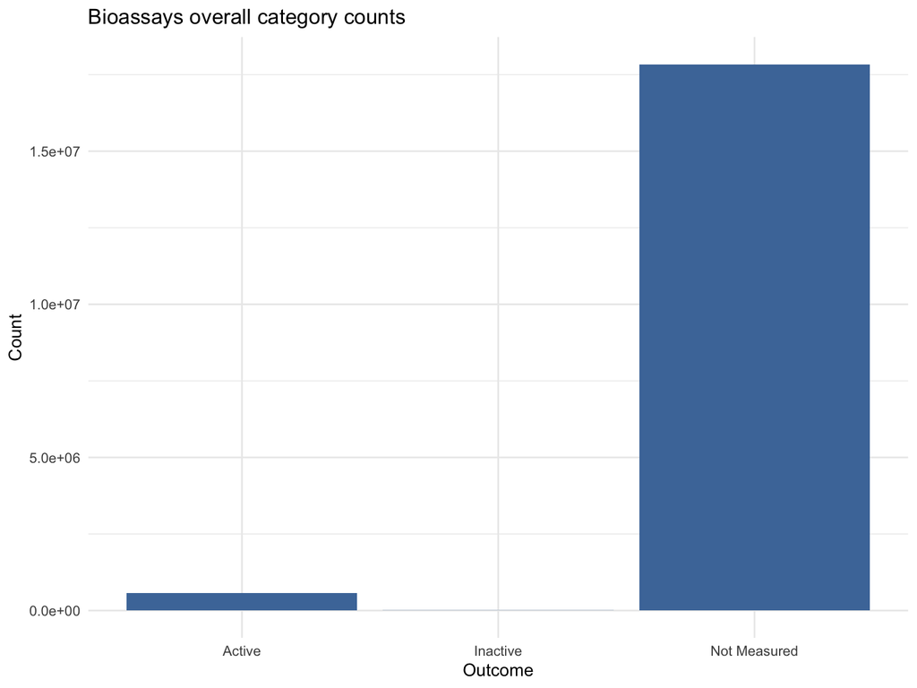

```r
bio_counts <- tibble::tibble(
  status = factor(
    names(category_counts),
    levels = c("Active", "Inactive", "Not Measured")
  ),
  count = as.numeric(category_counts)
)

bio_by_assay <- t(apply(assay_mat_chr, 1, function(values) {
  table(factor(
    ifelse(is.na(values), "Not Measured", as.character(values)),
    levels = c("Active", "Inactive", "Not Measured")
  ))
})) |>
  as.data.frame() |>
  tibble::rownames_to_column("assay") |>
  tidyr::pivot_longer(-assay, names_to = "status", values_to = "count")

bio_by_assay$status <- factor(
  bio_by_assay$status,
  levels = c("Active", "Inactive", "Not Measured")
)

ggplot(bio_counts, aes(x = status, y = count)) +
  geom_col(fill = "#4C78A8") +
  labs(
    title = "Bioassays overall category counts",
    x = "Outcome",
    y = "Count"
  ) +
  theme_minimal()
```

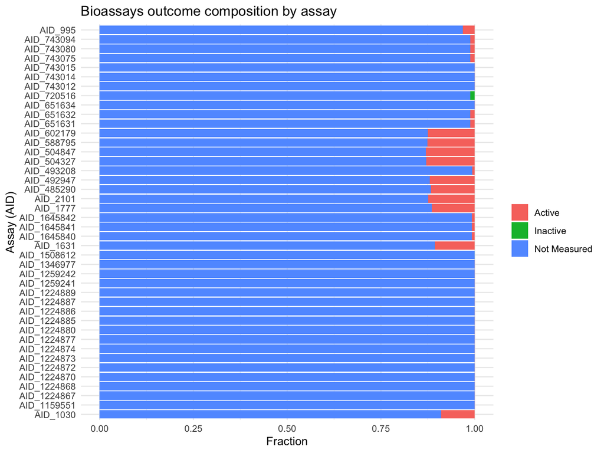

```r
ggplot(bio_by_assay, aes(x = assay, y = count, fill = status)) +
  geom_col(position = "fill") +
  coord_flip() +
  labs(
    title = "Bioassays outcome composition by assay",
    x = "Assay (AID)",
    y = "Fraction",
    fill = ""
  ) +
  theme_minimal()
```

## 5.2 Tox21

A compound-by-assay matrix for the Tox21 panel. Rows are Tox21 assays and columns are `HDD.Compound.ID` values. Values are typically binary (0/1) with missing values for unmeasured compounds.

```r
se <- experiments(hdd_mae)[["Tox21"]]
assay_mat <- assay(se)

c(rows = nrow(assay_mat), cols = ncol(assay_mat))
```

```
## rows cols
##   12 5944
```

```r
assay_mat[1:min(5, nrow(assay_mat)), 1:min(6, ncol(assay_mat))]
```

|  | HDD_YC9Gf2T0Yv9G | HDD_205XDwe3PHWH | HDD_ChOFSY4yK7t2 | HDD_bf2VbS2Nt8VF | HDD_4vavUI6z5Alr | HDD_Acqq5zsqdHSe |
| --- | --- | --- | --- | --- | --- | --- |
| NR-AR | 0 | NA | 0 | 0 | 0 | 0 |
| NR-AR-LBD | 0 | NA | 0 | 0 | NA | NA |
| NR-AhR | 0 | NA | 0 | 0 | 1 | 1 |
| NR-Aromatase | 0 | NA | 0 | 0 | NA | NA |
| NR-ER | 0 | NA | 0 | 0 | NA | NA |

```r
# Value distribution
assay_mat_num <- as.matrix(assay_mat)
if ("mol_id" %in% rownames(assay_mat_num)) {
  assay_mat_num <- assay_mat_num[
    rownames(assay_mat_num) != "mol_id",
    ,
    drop = FALSE
  ]
}
table(as.vector(assay_mat_num), useNA = "ifany")
```

```
##
##     0     1  <NA>
## 54632  4697 11999
```

```r
# Missingness per assay
summary(rowMeans(is.na(assay_mat_num)))
```

```
##    Min. 1st Qu.  Median    Mean 3rd Qu.    Max.
##  0.0722  0.1291  0.1633  0.1682  0.2162  0.2635
```

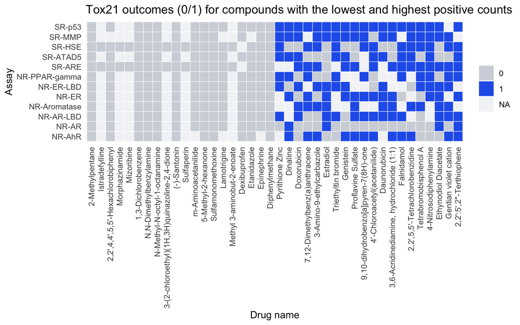

```r
tox21_long <- as.data.frame(assay_mat_num) |>
  tibble::rownames_to_column("assay") |>
  tidyr::pivot_longer(-assay, names_to = "compound", values_to = "value")
tox21_long$value_factor <- factor(tox21_long$value, levels = c(0, 1))

tox21_compound_summary <- tox21_long |>
  group_by(compound) |>
  summarize(positive_count = sum(value == 1, na.rm = TRUE), .groups = "drop") |>
  left_join(compound_labels, by = c("compound" = "sample_id")) |>
  arrange(positive_count, compound)

tox21_plot_compounds <- bind_rows(
  tox21_compound_summary |> slice_head(n = 20) |> mutate(group = "Bottom 20"),
  tox21_compound_summary |> slice_tail(n = 20) |> mutate(group = "Top 20")
) |>
  distinct(compound, .keep_all = TRUE) |>
  arrange(positive_count, compound)

tox21_plot <- tox21_long |>
  filter(compound %in% tox21_plot_compounds$compound) |>
  left_join(
    tox21_plot_compounds |>
      select(compound, compound_label),
    by = "compound"
  ) |>
  mutate(
    compound_label = factor(
      compound_label,
      levels = tox21_plot_compounds$compound_label
    )
  )

ggplot(tox21_plot, aes(x = compound_label, y = assay, fill = value_factor)) +
  geom_tile(color = "white") +
  scale_fill_manual(
    values = c("0" = "#d1d5db", "1" = "#2563eb"),
    na.value = "#f3f4f6"
  ) +
  labs(
    title = "Tox21 outcomes (0/1) for compounds with the lowest and highest positive counts",
    x = "Drug name",
    y = "Assay",
    fill = ""
  ) +
  theme_minimal() +
  theme(axis.text.x = element_text(angle = 90, vjust = 0.5, hjust = 1))
```

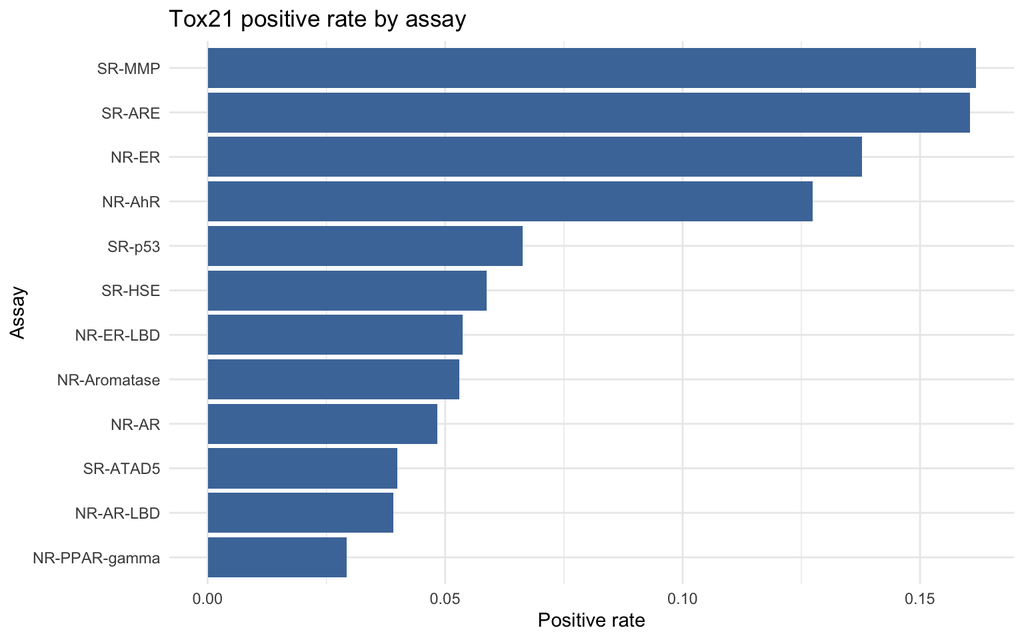

```r
tox21_rate <- tox21_long |>
  group_by(assay) |>
  summarize(positive_rate = mean(value == 1, na.rm = TRUE), .groups = "drop")

ggplot(tox21_rate, aes(x = reorder(assay, positive_rate), y = positive_rate)) +
  geom_col(fill = "#4C78A8") +
  coord_flip() +
  labs(
    title = "Tox21 positive rate by assay",
    x = "Assay",
    y = "Positive rate"
  ) +
  theme_minimal()
```

## 5.3 ToxCast

A compound-by-assay matrix for the ToxCast panel. Rows are assay endpoints and columns are `HDD.Compound.ID` values. Values are typically binary (0/1) with missing values.

```r
se <- experiments(hdd_mae)[["ToxCast"]]
assay_mat <- assays(se)[[1]]

c(rows = nrow(assay_mat), cols = ncol(assay_mat))
```

```
## rows cols
##  617 6694
```

```r
assay_mat[1:min(5, nrow(assay_mat)), 1:min(6, ncol(assay_mat))]
```

|  | HDD_Eu6RTc0YYBEV | HDD_HNldZL6hjpUT | HDD_2DH00HKGhmCq | HDD_TlE5yNnakXa5 | HDD_XO4jj85FuljE | HDD_pX00Xmgt0hEJ |
| --- | --- | --- | --- | --- | --- | --- |
| ACEA_T47D_80hr_Negative | NA | NA | NA | NA | NA | NA |
| ACEA_T47D_80hr_Positive | NA | NA | NA | NA | NA | NA |
| APR_HepG2_CellCycleArrest_24h_dn | NA | NA | NA | NA | NA | NA |
| APR_HepG2_CellCycleArrest_24h_up | NA | NA | NA | NA | NA | NA |
| APR_HepG2_CellCycleArrest_72h_dn | NA | NA | NA | NA | NA | NA |

```r
# Value distribution
assay_mat_num <- as.matrix(assay_mat)
table(as.vector(assay_mat_num), useNA = "ifany")
```

```
##
##       0       1    <NA>
## 1116266  103288 2910644
```

```r
# Missingness per assay
summary(rowMeans(is.na(assay_mat_num)))
```

```
##    Min. 1st Qu.  Median    Mean 3rd Qu.    Max.
##  0.0687  0.5949  0.8239  0.7047  0.9634  0.9939
```

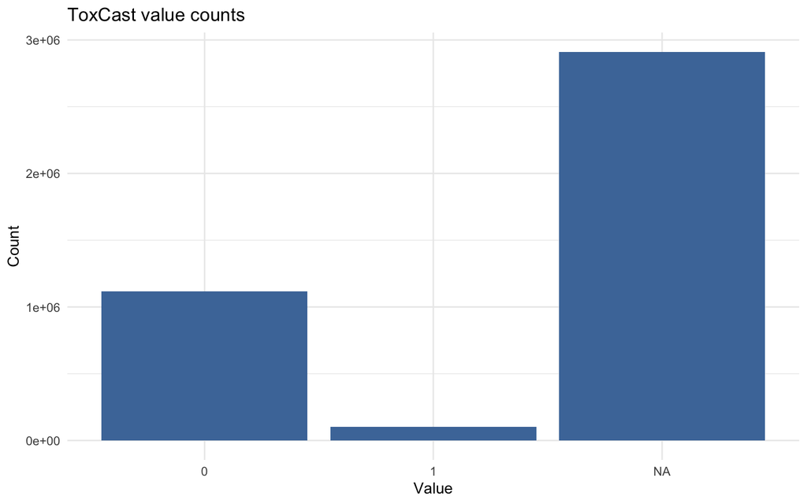

```r
toxcast_counts <- as.data.frame(table(
  value = as.vector(assay_mat_num),
  useNA = "ifany"
))

ggplot(toxcast_counts, aes(x = value, y = Freq)) +
  geom_col(fill = "#4C78A8") +
  labs(
    title = "ToxCast value counts",
    x = "Value",
    y = "Count"
  ) +
  theme_minimal()
```

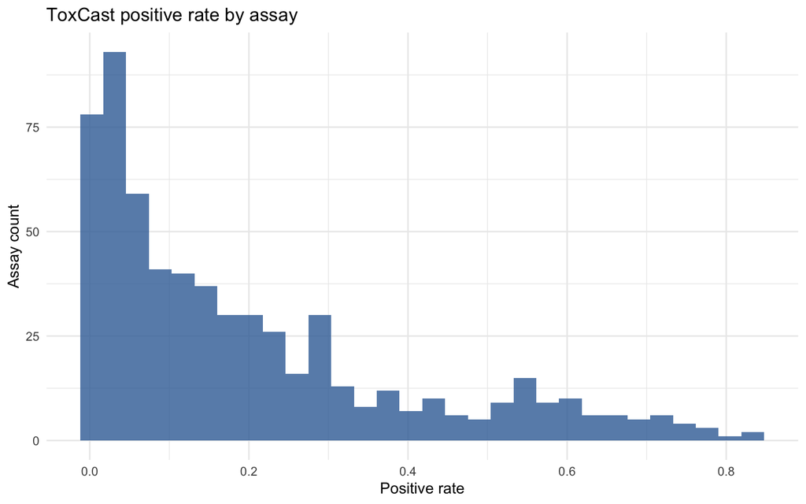

```r
row_non_missing <- rowSums(!is.na(assay_mat_num))
row_positive <- rowSums(assay_mat_num == 1, na.rm = TRUE)
row_rate <- row_positive / row_non_missing
row_rate <- row_rate[!is.na(row_rate)]

ggplot(tibble::tibble(positive_rate = row_rate), aes(x = positive_rate)) +
  geom_histogram(bins = 30, fill = "#3A6EA5", alpha = 0.8) +
  labs(
    title = "ToxCast positive rate by assay",
    x = "Positive rate",
    y = "Assay count"
  ) +
  theme_minimal()
```

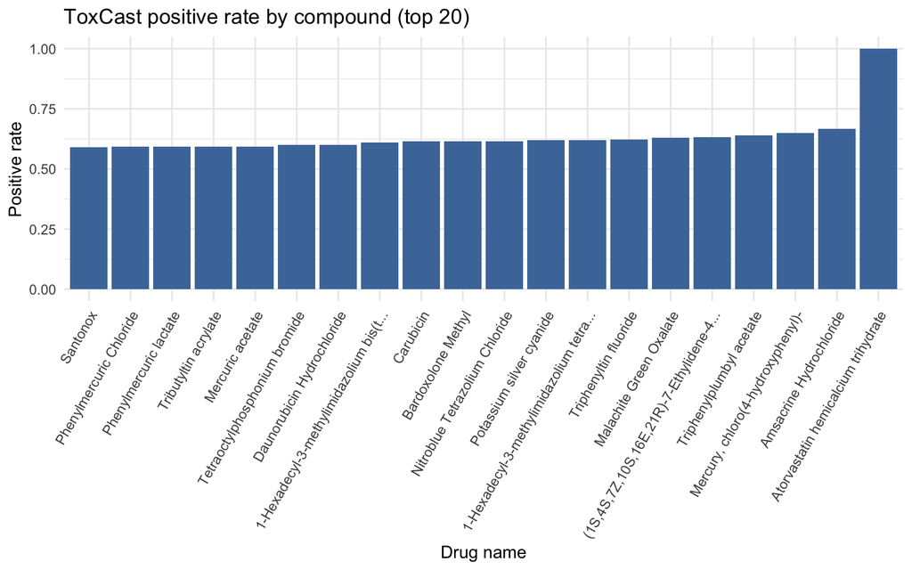

```r
col_non_missing <- colSums(!is.na(assay_mat_num))
col_positive <- colSums(assay_mat_num == 1, na.rm = TRUE)
col_rate <- col_positive / col_non_missing
toxcast_compound <- tibble::tibble(
  compound = colnames(assay_mat_num),
  positive_rate = as.numeric(col_rate)
) |>
  left_join(compound_labels, by = c("compound" = "sample_id")) |>
  arrange(positive_rate, compound)

toxcast_top_compounds <- toxcast_compound |>
  slice_tail(n = 20) |>
  arrange(positive_rate, compound) |>
  mutate(
    display_label = ifelse(
      nchar(compound_label) > 40,
      paste0(substr(compound_label, 1, 37), "..."),
      compound_label
    ),
    display_label = factor(
      make.unique(display_label),
      levels = make.unique(display_label)
    )
  )

ggplot(
  toxcast_top_compounds,
  aes(x = display_label, y = positive_rate)
) +
  geom_col(fill = "#4C78A8") +
  labs(
    title = "ToxCast positive rate by compound (top 20)",
    x = "Drug name",
    y = "Positive rate"
  ) +
  theme_minimal() +
  theme(axis.text.x = element_text(angle = 60, hjust = 1, vjust = 1))
```

## 5.4 ClinTox

A compound-by-label matrix for clinical toxicity outcomes. Rows correspond to the ClinTox labels (e.g., FDA approval and toxicity) and columns are `HDD.Compound.ID` values. Values are binary (0/1) with missing values for compounds not present in the source dataset.

```r
se <- experiments(hdd_mae)[["ClinTox"]]
assay_mat <- assay(se)

c(rows = nrow(assay_mat), cols = ncol(assay_mat))
```

```
## rows cols
##    2  924
```

```r
assay_mat[1:min(5, nrow(assay_mat)), 1:min(6, ncol(assay_mat))]
```

|  | HDD_NclS1POFzedt | HDD_R714iNre6dNv | HDD_cH6u1VSM2xZQ | HDD_fTQMldyKa6y2 | HDD_UFmFFOt0GHWB | HDD_8CTmG0j8m3Ur |
| --- | --- | --- | --- | --- | --- | --- |
| FDA_APPROVED | 1 | 1 | 1 | 1 | 1 | 0 |
| CT_TOX | 0 | 0 | 0 | 0 | 0 | 1 |

```r
# Value distribution
assay_mat_num <- as.matrix(assay_mat)
table(as.vector(assay_mat_num), useNA = "ifany")
```

```
##
##   0   1
## 906 942
```

```r
# Missingness per label
summary(rowMeans(is.na(assay_mat_num)))
```

```
##    Min. 1st Qu.  Median    Mean 3rd Qu.    Max.
##       0       0       0       0       0       0
```

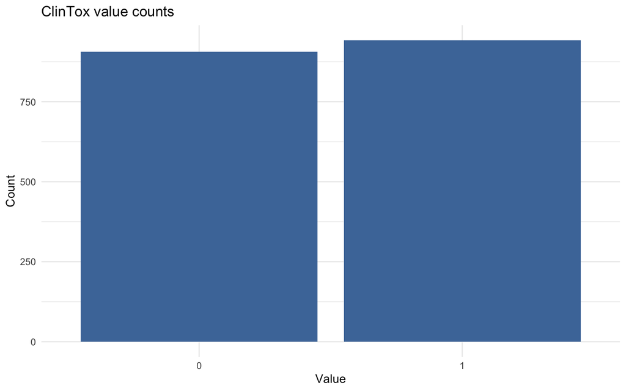

```r
clintox_counts <- as.data.frame(table(
  value = as.vector(assay_mat_num),
  useNA = "ifany"
))

ggplot(clintox_counts, aes(x = value, y = Freq)) +
  geom_col(fill = "#4C78A8") +
  labs(
    title = "ClinTox value counts",
    x = "Value",
    y = "Count"
  ) +
  theme_minimal()
```

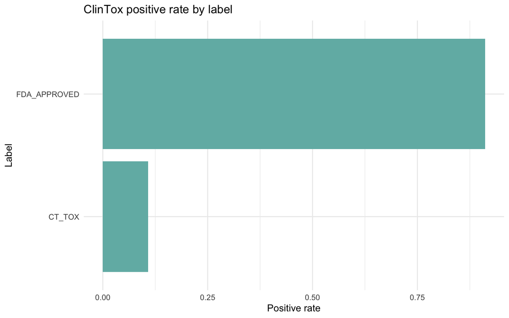

```r
row_non_missing <- rowSums(!is.na(assay_mat_num))
row_positive <- rowSums(assay_mat_num == 1, na.rm = TRUE)
row_rate <- row_positive / row_non_missing

clintox_label <- tibble::tibble(
  label = rownames(assay_mat_num),
  positive_rate = as.numeric(row_rate)
)

ggplot(
  clintox_label,
  aes(x = reorder(label, positive_rate), y = positive_rate)
) +
  geom_col(fill = "#72B7B2") +
  coord_flip() +
  labs(
    title = "ClinTox positive rate by label",
    x = "Label",
    y = "Positive rate"
  ) +
  theme_minimal()
```

## 5.5 SIDER

A compound-by-side-effect matrix derived from SIDER. Rows are side effect categories and columns are `HDD.Compound.ID` values. Values are binary (0/1) with missing values when a compound is not represented.

```r
se <- experiments(hdd_mae)[["SIDER"]]
assay_mat <- assay(se)

c(rows = nrow(assay_mat), cols = ncol(assay_mat))
```

```
## rows cols
##   27 1396
```

```r
assay_mat[1:min(5, nrow(assay_mat)), 1:min(6, ncol(assay_mat))]
```

```
##                                    HDD_g4c0MtgygYwz HDD_loKuBSSVVExm
## Hepatobiliary disorders                           1                0
## Metabolism and nutrition disorders                1                1
## Product issues                                    0                0
## Eye disorders                                     0                0
## Investigations                                    1                1
##                                    HDD_bn4qZQZNf8lw HDD_PDmrpvRaQUTU
## Hepatobiliary disorders                           0                1
## Metabolism and nutrition disorders                1                1
## Product issues                                    0                0
## Eye disorders                                     1                1
## Investigations                                    1                1
##                                    HDD_rOPijtNimrd1 HDD_MwdiJlr9ygRr
## Hepatobiliary disorders                           1                0
## Metabolism and nutrition disorders                1                1
## Product issues                                    0                0
## Eye disorders                                     1                1
## Investigations                                    1                1
```

```r
# Value distribution
assay_mat_num <- as.matrix(assay_mat)
table(as.vector(assay_mat_num), useNA = "ifany")
```

```
##
##     0     1
## 16315 21377
```

```r
# Missingness per side effect
summary(rowMeans(is.na(assay_mat_num)))
```

```
##    Min. 1st Qu.  Median    Mean 3rd Qu.    Max.
##       0       0       0       0       0       0
```

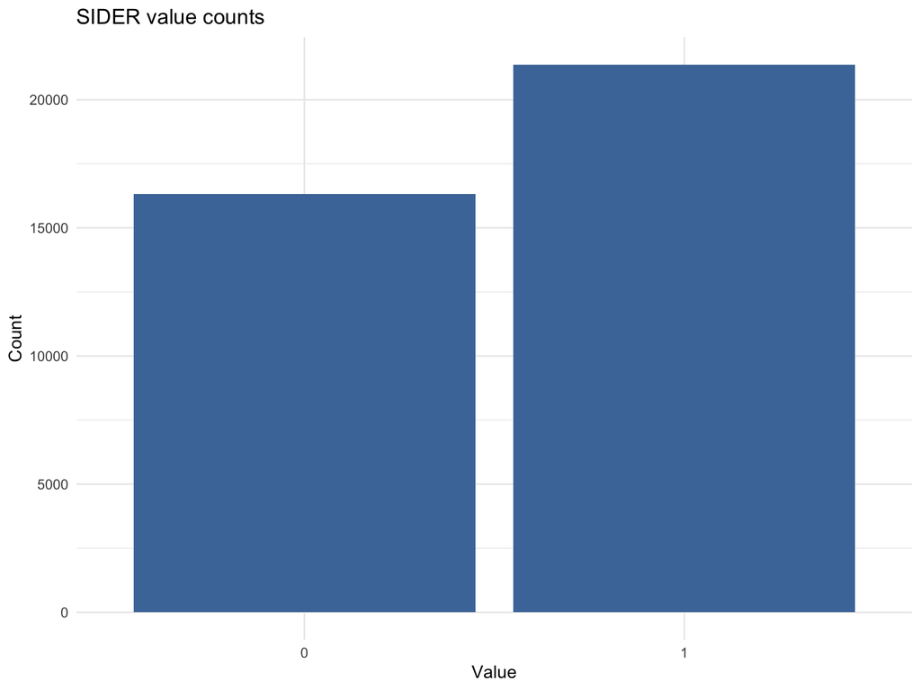

```r
sider_counts <- as.data.frame(table(
  value = as.vector(assay_mat_num),
  useNA = "ifany"
))

ggplot(sider_counts, aes(x = value, y = Freq)) +
  geom_col(fill = "#4C78A8") +
  labs(
    title = "SIDER value counts",
    x = "Value",
    y = "Count"
  ) +
  theme_minimal()
```

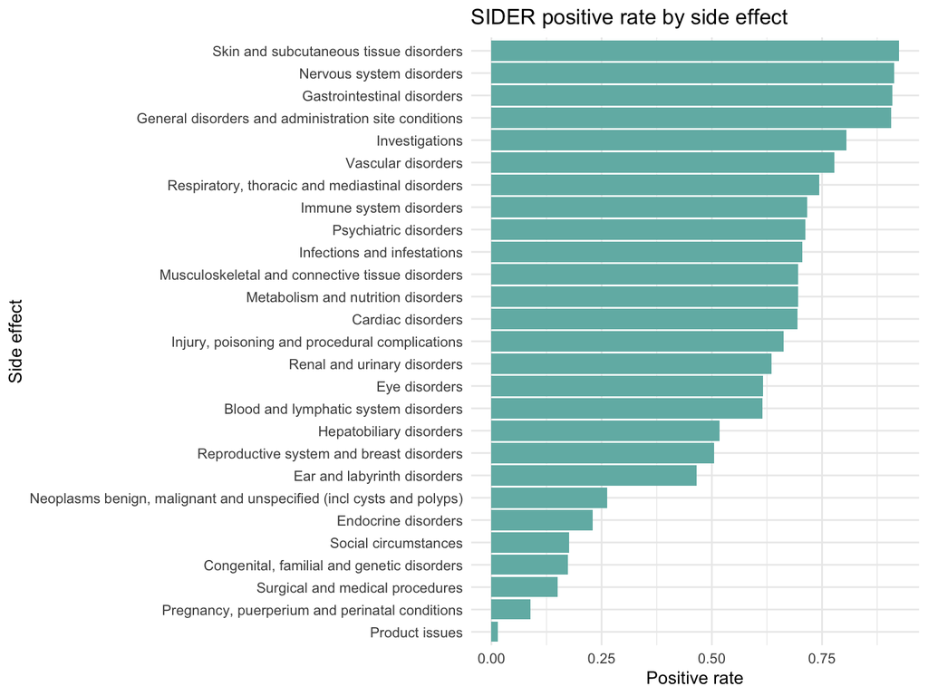

```r
row_non_missing <- rowSums(!is.na(assay_mat_num))
row_positive <- rowSums(assay_mat_num == 1, na.rm = TRUE)
row_rate <- row_positive / row_non_missing

sider_effects <- tibble::tibble(
  side_effect = rownames(assay_mat_num),
  positive_rate = as.numeric(row_rate)
)

ggplot(
  sider_effects,
  aes(x = reorder(side_effect, positive_rate), y = positive_rate)
) +
  geom_col(fill = "#72B7B2") +
  coord_flip() +
  labs(
    title = "SIDER positive rate by side effect",
    x = "Side effect",
    y = "Positive rate"
  ) +
  theme_minimal()
```

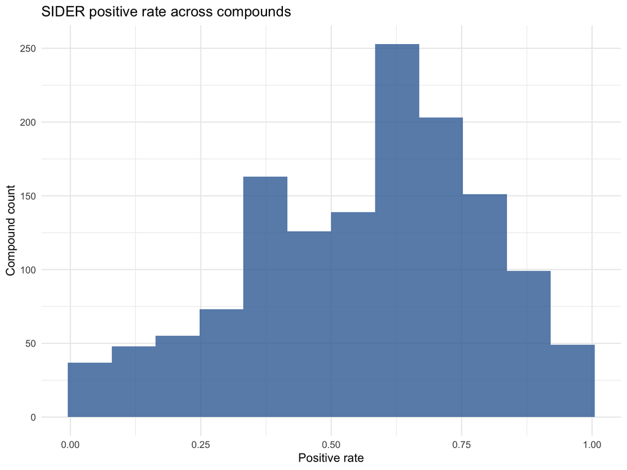

```r
col_non_missing <- colSums(!is.na(assay_mat_num))
col_positive <- colSums(assay_mat_num == 1, na.rm = TRUE)
col_rate <- col_positive / col_non_missing

ggplot(tibble::tibble(positive_rate = col_rate), aes(x = positive_rate)) +
  geom_histogram(bins = 12, fill = "#3A6EA5", alpha = 0.8) +
  labs(
    title = "SIDER positive rate across compounds",
    x = "Positive rate",
    y = "Compound count"
  ) +
  theme_minimal()
```

## 5.6 Fingerprints (Morgan count fingerprints)

Count-based Morgan fingerprints generated from parseable SMILES using RDKit. Each fingerprint experiment is stored as a sparse matrix of feature counts with rows as fingerprint bins and columns as the `HDD.Compound.ID` values that produced a fingerprint. Compounds with missing or invalid SMILES remain in `colData` but are not columns in the fingerprint experiments.

```r
fp_names <- grep("^fingerprint\\.", experiment_names, value = TRUE)
fp_names
```

```
## [1] "fingerprint.Morgan.2.1024" "fingerprint.Morgan.2.2048"
## [3] "fingerprint.Morgan.3.1024" "fingerprint.Morgan.3.2048"
```

```r
preferred_fp_names <- c(
  "fingerprint.Morgan.3.1024",
  "fingerprint.Morgan.3.2048",
  "fingerprint.Morgan.2.1024",
  "fingerprint.Morgan.2.2048"
)
selected_fp_name <- preferred_fp_names[preferred_fp_names %in% fp_names][1]
selected_fp_name
```

```
## [1] "fingerprint.Morgan.3.1024"
```

```r
fingerprint_coverage <- tibble::tibble(
  total_compounds = nrow(cd),
  compounds_with_smiles = sum(!is.na(cd$SMILES)),
  selected_fingerprint_columns = if (is.na(selected_fp_name)) {
    NA_integer_
  } else {
    ncol(assay(experiments(hdd_mae)[[selected_fp_name]]))
  },
  not_fingerprinted = total_compounds - selected_fingerprint_columns
)

fingerprint_coverage
```

| total_compounds | compounds_with_smiles | selected_fingerprint_columns | not_fingerprinted |
| --- | --- | --- | --- |
| 648122 | 647143 | 646039 | 2083 |

```r
for (fp_name in fp_names) {
  se <- experiments(hdd_mae)[[fp_name]]
  assay_mat <- assays(se)[[1]]

  cat("\nFingerprint:", fp_name, "\n")
  cat("Dimensions:", nrow(assay_mat), "x", ncol(assay_mat), "\n")

  # Sparsity for sparse matrices
  if (inherits(assay_mat, "sparseMatrix")) {
    sparsity <- 1 - Matrix::nnzero(assay_mat) / length(assay_mat)
    cat("Sparsity:", round(sparsity, 4), "\n")
  }

  print(assay_mat[1:min(5, nrow(assay_mat)), 1:min(6, ncol(assay_mat))])
}
```

```
##
## Fingerprint: fingerprint.Morgan.2.1024
## Dimensions: 1024 x 646039
## Sparsity: 0.956
## 5 x 6 sparse Matrix of class "dgCMatrix"
##    HDD_100Qq7ZWzc84 HDD_100VcBf7xNmF HDD_100qxkzFVw1Y HDD_101gEGLkpWU6
## V1                .                .                .                .
## V2                1                .                .                .
## V3                .                .                .                .
## V4                .                .                .                .
## V5                .                .                .                .
##    HDD_101w9WD4OfLl HDD_101xneHl8ces
## V1                .                .
## V2                .                .
## V3                .                .
## V4                .                .
## V5                .                .
##
## Fingerprint: fingerprint.Morgan.2.2048
## Dimensions: 2048 x 646039
## Sparsity: 0.978
## 5 x 6 sparse Matrix of class "dgCMatrix"
##    HDD_100Qq7ZWzc84 HDD_100VcBf7xNmF HDD_100qxkzFVw1Y HDD_101gEGLkpWU6
## V1                .                .                .                .
## V2                1                .                .                .
## V3                .                .                .                .
## V4                .                .                .                .
## V5                .                .                .                .
##    HDD_101w9WD4OfLl HDD_101xneHl8ces
## V1                .                .
## V2                .                .
## V3                .                .
## V4                .                .
## V5                .                .
##
## Fingerprint: fingerprint.Morgan.3.1024
## Dimensions: 1024 x 646039
## Sparsity: 0.941
## 5 x 6 sparse Matrix of class "dgCMatrix"
##    HDD_100Qq7ZWzc84 HDD_100VcBf7xNmF HDD_100qxkzFVw1Y HDD_101gEGLkpWU6
```

[output cut: 13 more lines]

```
## Dimensions: 2048 x 646039
## Sparsity: 0.97
## 5 x 6 sparse Matrix of class "dgCMatrix"
##    HDD_100Qq7ZWzc84 HDD_100VcBf7xNmF HDD_100qxkzFVw1Y HDD_101gEGLkpWU6
## V1                .                .                .                .
## V2                1                .                .                .
## V3                .                .                .                .
## V4                .                .                .                .
## V5                .                .                .                .
##    HDD_101w9WD4OfLl HDD_101xneHl8ces
## V1                .                .
## V2                .                .
## V3                .                .
## V4                .                .
## V5                .                .
```

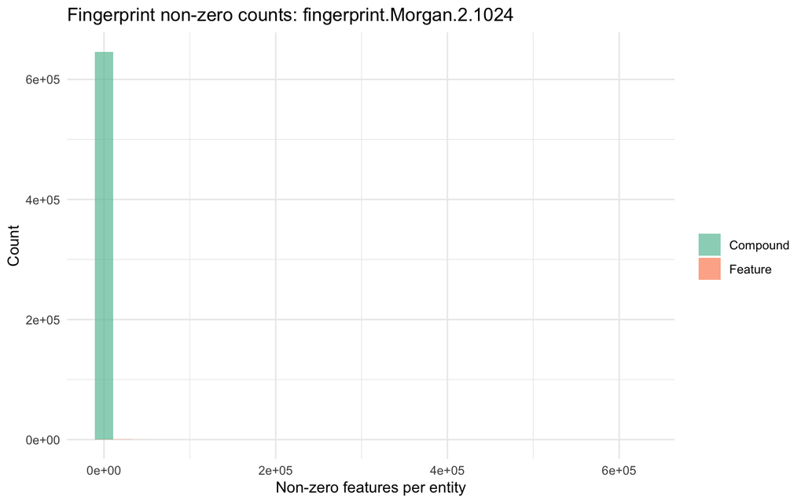

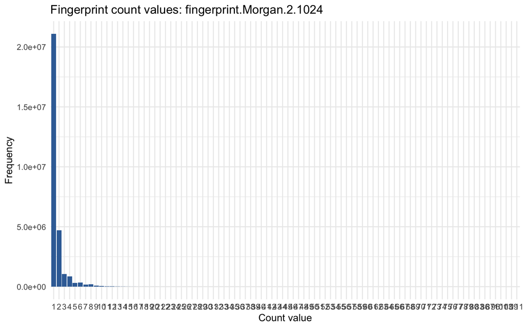

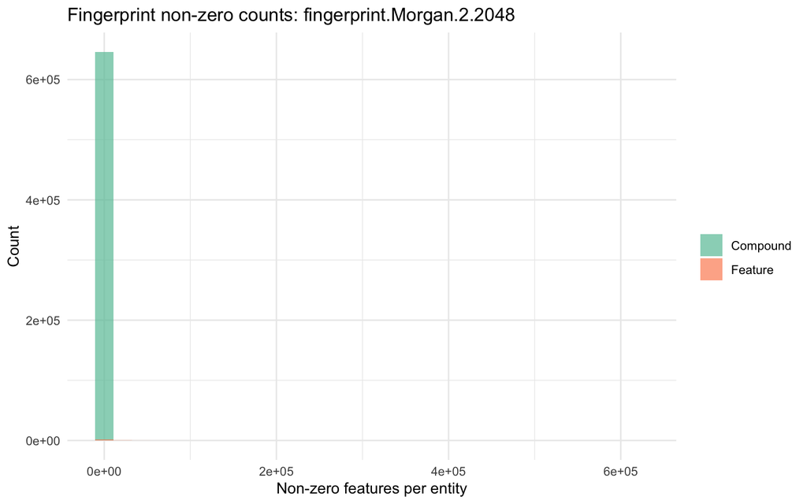

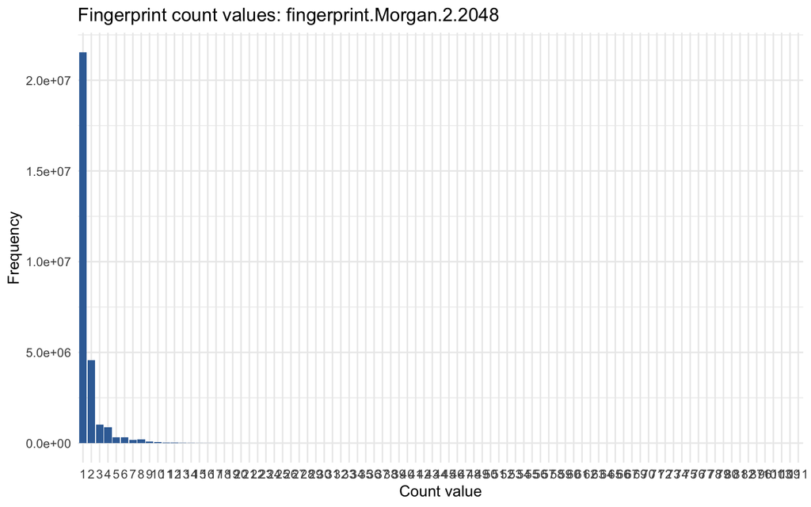

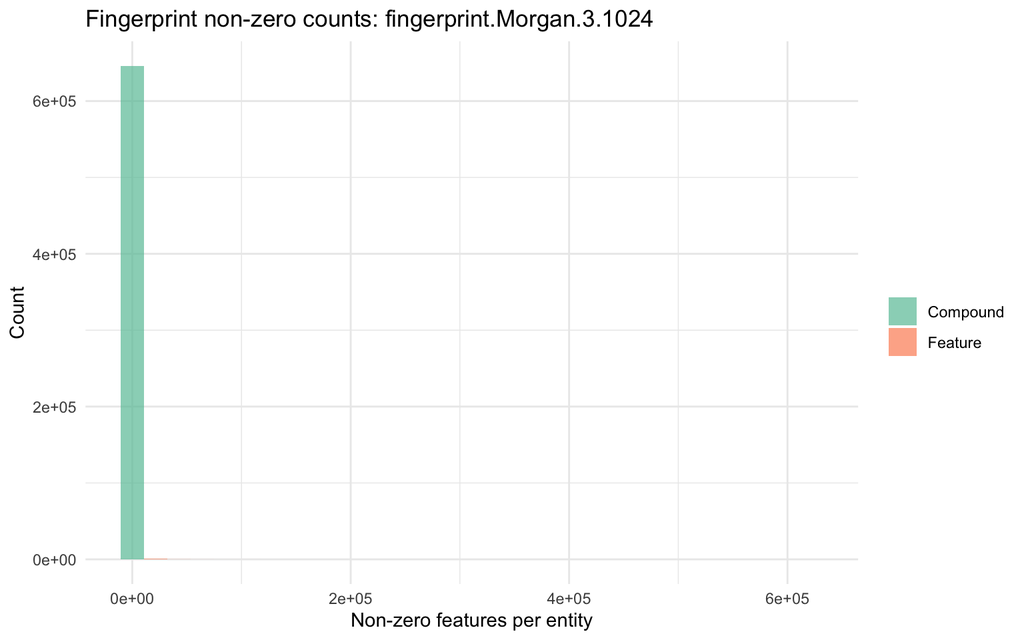

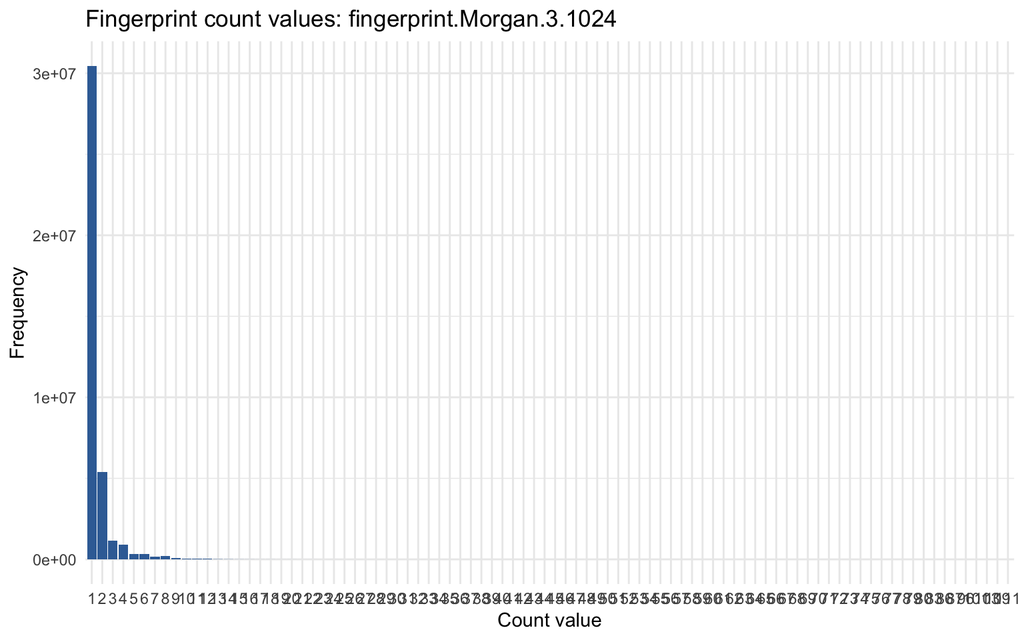

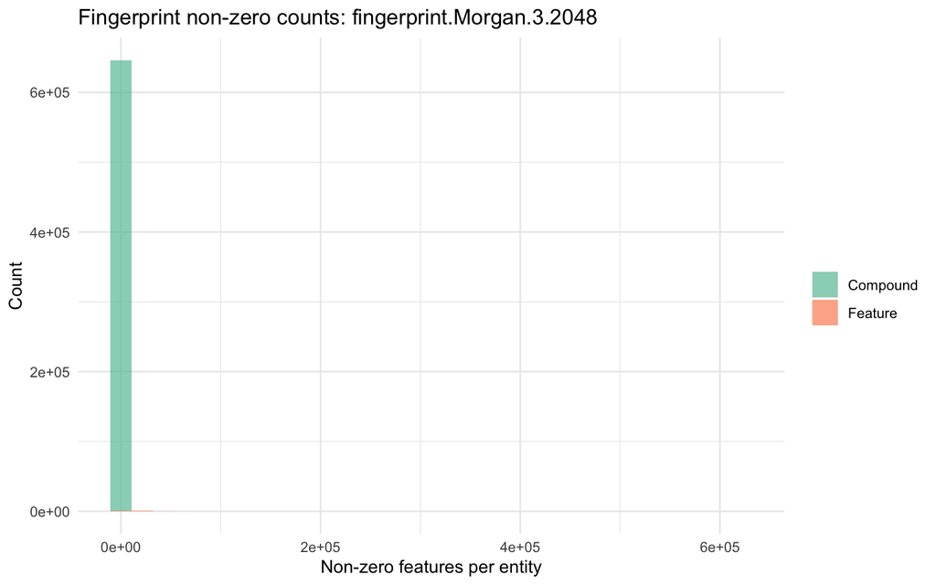

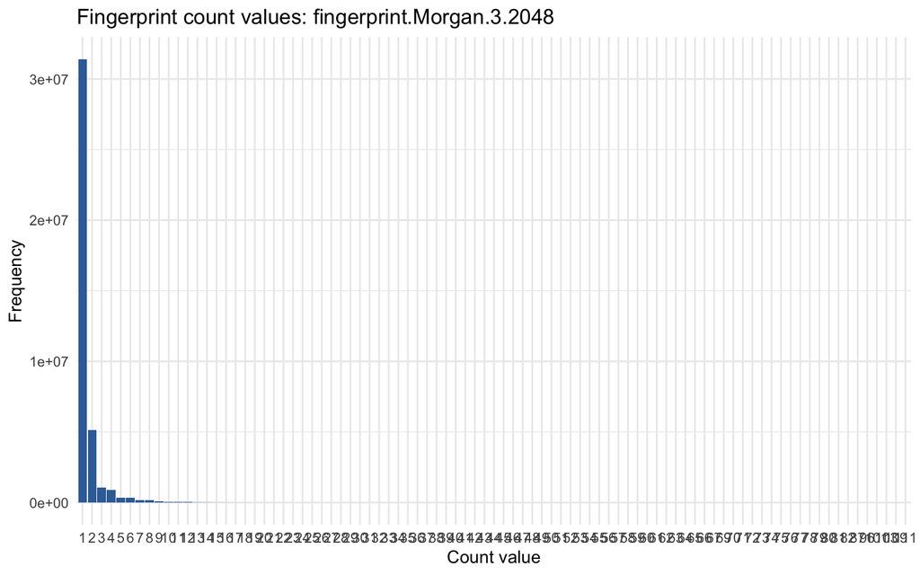

```r
for (fp_name in fp_names) {
  se <- experiments(hdd_mae)[[fp_name]]
  assay_mat <- assays(se)[[1]]

  col_nnz <- Matrix::colSums(assay_mat > 0)
  row_nnz <- Matrix::rowSums(assay_mat > 0)

  nnz_df <- tibble::tibble(
    count = c(as.numeric(col_nnz), as.numeric(row_nnz)),
    axis = rep(c("Compound", "Feature"), c(length(col_nnz), length(row_nnz)))
  )

  p_nnz <- ggplot(nnz_df, aes(x = count, fill = axis)) +
    geom_histogram(bins = 30, alpha = 0.7, position = "identity") +
    scale_fill_brewer(palette = "Set2") +
    labs(
      title = paste("Fingerprint non-zero counts:", fp_name),
      x = "Non-zero features per entity",
      y = "Count",
      fill = ""
    ) +
    theme_minimal()

  nonzero_vals <- assay_mat@x
  val_df <- as.data.frame(table(value = nonzero_vals))

  p_vals <- ggplot(val_df, aes(x = value, y = Freq)) +
    geom_col(fill = "#3A6EA5") +
    labs(
      title = paste("Fingerprint count values:", fp_name),
      x = "Count value",
      y = "Frequency"
    ) +
    theme_minimal()

  print(p_nnz)
  print(p_vals)
}
```

## 5.7 ATC code coverage

AnnotationDB ATC data requires an authorization key. If the key is not set, the pipeline still builds the HDD with other AnnotationDB fields and leaves `ATC.Code` missing.

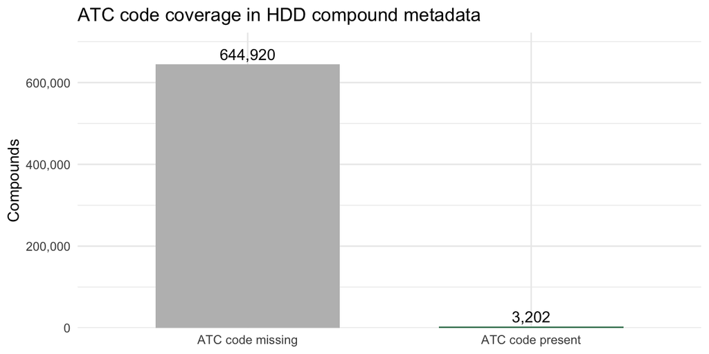

```r
stopifnot("ATC.Code" %in% colnames(cd))

atc_values <- trimws(as.character(cd$ATC.Code))
atc_coverage <- tibble::tibble(
  status = c("ATC code present", "ATC code missing"),
  compounds = c(
    sum(!is.na(atc_values) & atc_values != ""),
    sum(is.na(atc_values) | atc_values == "")
  )
)

ggplot(atc_coverage, aes(x = status, y = compounds, fill = status)) +
  geom_col(width = 0.65, show.legend = FALSE) +
  geom_text(aes(label = scales::comma(compounds)), vjust = -0.4) +
  scale_y_continuous(
    labels = scales::comma,
    expand = expansion(mult = c(0, 0.12))
  ) +
  scale_fill_manual(values = c(
    "ATC code present" = "#26734D",
    "ATC code missing" = "#BDBDBD"
  )) +
  labs(
    title = "ATC code coverage in HDD compound metadata",
    x = NULL,
    y = "Compounds"
  ) +
  theme_minimal(base_size = 11)
```

## 5.8 DILI, DIRIL, and DICT coverage

This section summarizes the toxicity metadata currently available in `colData` for liver, renal, and cardiac toxicity labels.

```r
col.Data <- colData(hdd_mae) |>
  as.data.frame()

source_toxicity_columns <- tibble::tribble(
  ~source, ~label_set, ~field, ~column,
  "LTKB", "LTKB Benchmark Dataset", "DILI severity grade",
  "LTKB.DILI.Severity.Grade",
  "LTKB", "LTKB Benchmark Dataset", "DILI annotation", "LTKB.DILI.Annotation",
  "LTKB", "DILIrank", "DILI severity grade", "DILIrank.DILI.Severity.Grade",
  "LTKB", "DILIrank", "DILI annotation", "DILIrank.DILI.Annotation",
  "LTKB", "DILIst", "DILI annotation", "DILIst.DILI.Annotation",
  "LiverTox", "LiverTox", "hepatotoxicity likelihood score",
  "Livertox.Hepatotoxicity.Likelihood.Score",
  "LiverTox", "LiverTox", "hepatotoxicity likelihood reason",
  "Livertox.Hepatotoxicity.Likelihood.Reason"
)

diril_dict_columns <- tibble::tribble(
  ~source, ~field, ~column,
  "DIRIL", "Gong label", "DIRIL.Label.Gong",
  "DIRIL", "Shi label", "DIRIL.Label.Shi",
  "DIRIL", "final toxicity label", "DIRIL.Toxicity",
  "DICT", "cardiotoxicity class", "DICT.Cardiotoxicity",
  "DICT", "label section", "DICT.Label.Section",
  "DICT", "concern", "DICT.Concern",
  "DICT", "keywords", "DICT.Keywords"
)

count_non_missing <- function(column) {
  values <- as.character(col.Data[[column]])
  sum(!is.na(values) & trimws(values) != "")
}

count_unique_non_missing <- function(column) {
  values <- as.character(col.Data[[column]])
  non_missing_values <- values[!is.na(values) & trimws(values) != ""]
  length(unique(non_missing_values))
}

source_toxicity_coverage <- source_toxicity_columns |>
  mutate(
    non_missing = vapply(column, count_non_missing, integer(1)),
    unique_non_missing = vapply(column, count_unique_non_missing, integer(1))
  )

source_toxicity_coverage |>
  select(source, label_set, field, non_missing, unique_non_missing)
```

| source | label_set | field | non_missing | unique_non_missing |
| --- | --- | --- | --- | --- |
| LTKB | LTKB Benchmark Dataset | DILI severity grade | 152 | 7 |
| LTKB | LTKB Benchmark Dataset | DILI annotation | 292 | 3 |
| LTKB | DILIrank | DILI severity grade | 1213 | 9 |
| LTKB | DILIrank | DILI annotation | 1213 | 6 |
| LTKB | DILIst | DILI annotation | 1177 | 2 |
| LiverTox | LiverTox | hepatotoxicity likelihood score | 803 | 42 |
| LiverTox | LiverTox | hepatotoxicity likelihood reason | 719 | 183 |

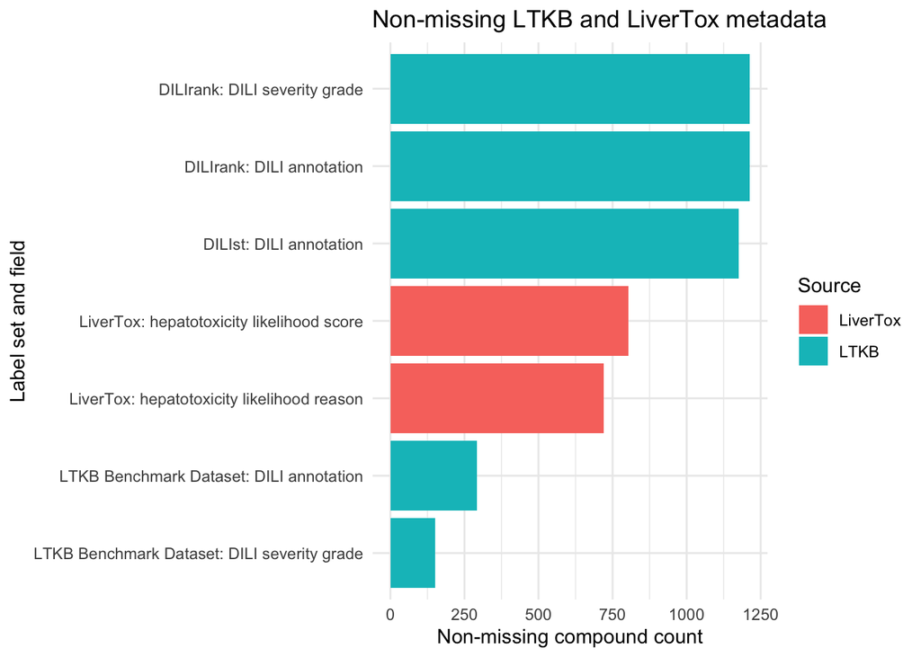

```r
ggplot(
  source_toxicity_coverage |>
    mutate(label = paste(label_set, field, sep = ": ")),
  aes(x = reorder(label, non_missing), y = non_missing, fill = source)
) +
  geom_col() +
  coord_flip() +
  labs(
    title = "Non-missing LTKB and LiverTox metadata",
    x = "Label set and field",
    y = "Non-missing compound count",
    fill = "Source"
  ) +
  theme_minimal()
```

```r
toxicity_label_count_columns <- bind_rows(
  source_toxicity_columns |>
    filter(field != "hepatotoxicity likelihood reason"),
  diril_dict_columns |>
    filter(field != "keywords")
)

toxicity_label_counts <- lapply(
  seq_len(nrow(toxicity_label_count_columns)),
  function(idx) {
    spec <- toxicity_label_count_columns[idx, ]
    values <- trimws(as.character(col.Data[[spec$column]]))

    tibble::tibble(
      source = spec$source,
      label_set = spec$label_set,
      field = spec$field,
      label = values
    ) |>
      filter(!is.na(label), label != "") |>
      count(source, label_set, field, label, sort = TRUE)
  }
) |>
  dplyr::bind_rows()

toxicity_label_counts
```

| source | label_set | field | label | n |
| --- | --- | --- | --- | --- |
| LTKB | LTKB Benchmark Dataset | DILI severity grade | 3 | 50 |
| LTKB | LTKB Benchmark Dataset | DILI severity grade | 8 | 48 |
| LTKB | LTKB Benchmark Dataset | DILI severity grade | 5 | 20 |
| LTKB | LTKB Benchmark Dataset | DILI severity grade | 2 | 13 |
| LTKB | LTKB Benchmark Dataset | DILI severity grade | 7 | 12 |
| LTKB | LTKB Benchmark Dataset | DILI severity grade | 4 | 5 |
| LTKB | LTKB Benchmark Dataset | DILI severity grade | 6 | 4 |
| LTKB | LTKB Benchmark Dataset | DILI annotation | most-DILI-concern | 131 |
| LTKB | LTKB Benchmark Dataset | DILI annotation | no-DILI-concern | 82 |
| LTKB | LTKB Benchmark Dataset | DILI annotation | less-DILI-concern drugs | 79 |

[output cut: 81 more lines]

```r
source_dili_severity_columns <- source_toxicity_columns |>
  filter(field == "DILI severity grade") |>
  pull(column)

dili_counts <- lapply(source_dili_severity_columns, function(column) {
  label_set_name <- source_toxicity_columns$label_set[
    match(column, source_toxicity_columns$column)
  ]

  tibble::tibble(
    label_set = label_set_name,
    column = column,
    severity_grade = trimws(as.character(col.Data[[column]]))
  ) |>
    filter(!is.na(severity_grade), severity_grade != "") |>
    count(label_set, column, severity_grade, sort = TRUE)
}) |>
  dplyr::bind_rows() |>
  mutate(
    severity_grade = factor(
      severity_grade,
      levels = sort(unique(as.numeric(severity_grade)))
    )
  )

dili_counts
```

| label_set | column | severity_grade | n |
| --- | --- | --- | --- |
| LTKB Benchmark Dataset | LTKB.DILI.Severity.Grade | 3 | 50 |
| LTKB Benchmark Dataset | LTKB.DILI.Severity.Grade | 8 | 48 |
| LTKB Benchmark Dataset | LTKB.DILI.Severity.Grade | 5 | 20 |
| LTKB Benchmark Dataset | LTKB.DILI.Severity.Grade | 2 | 13 |
| LTKB Benchmark Dataset | LTKB.DILI.Severity.Grade | 7 | 12 |
| LTKB Benchmark Dataset | LTKB.DILI.Severity.Grade | 4 | 5 |
| LTKB Benchmark Dataset | LTKB.DILI.Severity.Grade | 6 | 4 |
| DILIrank | DILIrank.DILI.Severity.Grade | 0 | 415 |
| DILIrank | DILIrank.DILI.Severity.Grade | 3 | 366 |
| DILIrank | DILIrank.DILI.Severity.Grade | 8 | 164 |

[output cut: 6 more lines]

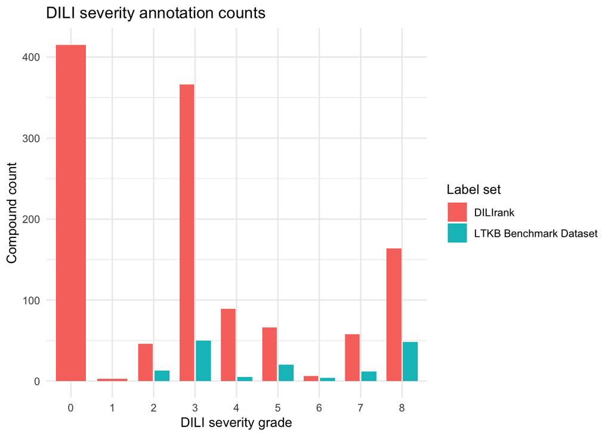

```r
ggplot(dili_counts, aes(x = severity_grade, y = n, fill = label_set)) +
  geom_col(position = position_dodge(width = 0.8), width = 0.72) +
  labs(
    title = "DILI severity annotation counts",
    x = "DILI severity grade",
    y = "Compound count",
    fill = "Label set"
  ) +
  theme_minimal()
```

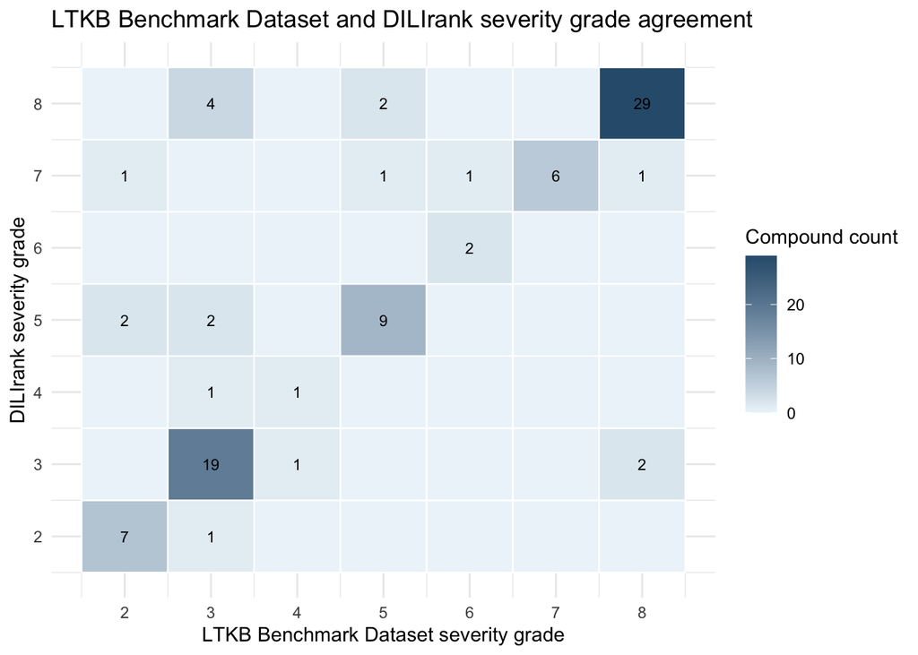

```r
dili_severity_consensus <- col.Data |>
  transmute(
    LTKB = suppressWarnings(
      as.integer(trimws(as.character(LTKB.DILI.Severity.Grade)))
    ),
    DILIrank = suppressWarnings(
      as.integer(trimws(as.character(DILIrank.DILI.Severity.Grade)))
    )
  ) |>
  filter(!is.na(LTKB), !is.na(DILIrank)) |>
  count(LTKB, DILIrank, name = "n") |>
  tidyr::complete(
    LTKB = seq(min(LTKB), max(LTKB)),
    DILIrank = seq(min(DILIrank), max(DILIrank)),
    fill = list(n = 0L)
  )

ggplot(dili_severity_consensus, aes(x = LTKB, y = DILIrank, fill = n)) +
  geom_tile(color = "white", linewidth = 0.4) +
  geom_text(aes(label = ifelse(n > 0, n, "")), size = 3) +
  scale_x_continuous(breaks = sort(unique(dili_severity_consensus$LTKB))) +
  scale_y_continuous(breaks = sort(unique(dili_severity_consensus$DILIrank))) +
  scale_fill_gradient(low = "#EDF5FA", high = "#2F5D7C") +
  labs(
    title = "LTKB Benchmark Dataset and DILIrank severity grade agreement",
    x = "LTKB Benchmark Dataset severity grade",
    y = "DILIrank severity grade",
    fill = "Compound count"
  ) +
  theme_minimal()
```

```r
diril_dict_coverage <- diril_dict_columns |>
  mutate(
    non_missing = vapply(column, count_non_missing, integer(1)),
    unique_non_missing = vapply(column, count_unique_non_missing, integer(1))
  )

diril_dict_coverage
```

| source | field | column | non_missing | unique_non_missing |
| --- | --- | --- | --- | --- |
| DIRIL | Gong label | DIRIL.Label.Gong | 176 | 2 |
| DIRIL | Shi label | DIRIL.Label.Shi | 255 | 2 |
| DIRIL | final toxicity label | DIRIL.Toxicity | 317 | 2 |
| DICT | cardiotoxicity class | DICT.Cardiotoxicity | 793 | 3 |
| DICT | label section | DICT.Label.Section | 1198 | 8 |
| DICT | concern | DICT.Concern | 1198 | 5 |
| DICT | keywords | DICT.Keywords | 974 | 552 |

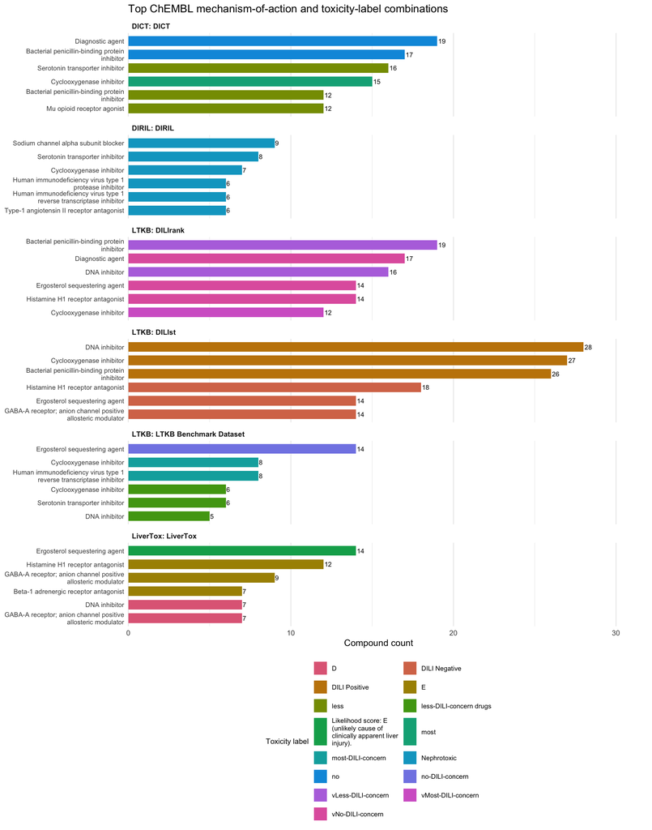

```r
moa_toxicity_label_columns <- tibble::tribble(
  ~source, ~label_set, ~field, ~column,
  "LTKB", "LTKB Benchmark Dataset", "DILI annotation", "LTKB.DILI.Annotation",
  "LTKB", "DILIrank", "DILI annotation", "DILIrank.DILI.Annotation",
  "LTKB", "DILIst", "DILI annotation", "DILIst.DILI.Annotation",
  "LiverTox", "LiverTox", "hepatotoxicity likelihood score",
  "Livertox.Hepatotoxicity.Likelihood.Score",
  "DIRIL", "DIRIL", "final toxicity label", "DIRIL.Toxicity",
  "DICT", "DICT", "concern", "DICT.Concern"
)

moa_toxicity_labels <- lapply(
  seq_len(nrow(moa_toxicity_label_columns)),
  function(idx) {
    spec <- moa_toxicity_label_columns[idx, ]
    moa <- trimws(as.character(col.Data$Mechanism.of.Action))
    label <- trimws(as.character(col.Data[[spec$column]]))

    tibble::tibble(
      source = spec$source,
      label_set = spec$label_set,
      field = spec$field,
      moa = moa,
      toxicity_label = label
    ) |>
      filter(
        !is.na(moa),
        moa != "",
        !is.na(toxicity_label),
        toxicity_label != ""
      )
  }
) |>
  dplyr::bind_rows()

wrap_plot_label <- function(value, width = 34) {
  vapply(
    value,
    function(item) {
      item <- trimws(as.character(item))
      if (is.na(item) || item == "") {
        return(NA_character_)
      }
      paste(strwrap(item, width = width), collapse = "\n")
    },
    character(1),
    USE.NAMES = FALSE
  )
}

moa_toxicity_counts <- moa_toxicity_labels |>
  count(source, label_set, field, moa, toxicity_label, sort = TRUE)

n_top_moa_toxicity_pairs <- 6

moa_toxicity_plot_data <- moa_toxicity_counts |>
  arrange(source, label_set, desc(n), moa, toxicity_label) |>
  group_by(source, label_set) |>
  slice_head(n = n_top_moa_toxicity_pairs) |>
  mutate(
    pair_rank = row_number(),
    pair_label = wrap_plot_label(moa, 42),
    toxicity_label_plot = wrap_plot_label(toxicity_label, 28),
    panel = paste(source, label_set, sep = ": "),
    pair_key = paste(panel, pair_rank, pair_label, sep = "|||")
  ) |>
  ungroup() |>
  arrange(source, label_set, desc(pair_rank)) |>
  mutate(
    source = factor(source, levels = unique(moa_toxicity_label_columns$source)),
    panel = factor(panel, levels = unique(panel)),
    pair_key = factor(pair_key, levels = unique(pair_key)),
    toxicity_label_plot = factor(
      toxicity_label_plot,
      levels = sort(unique(toxicity_label_plot))
    )
  )

toxicity_label_palette <- setNames(
  grDevices::hcl.colors(
    n = length(levels(moa_toxicity_plot_data$toxicity_label_plot)),
    palette = "Dark 3"
  ),
  levels(moa_toxicity_plot_data$toxicity_label_plot)
)

ggplot(
  moa_toxicity_plot_data,
  aes(x = n, y = pair_key, fill = toxicity_label_plot)
) +
  geom_col(width = 0.72) +
  geom_text(aes(label = n), hjust = -0.15, size = 2.8) +
  facet_wrap(~panel, scales = "free_y", ncol = 1) +
  scale_fill_manual(values = toxicity_label_palette) +
  scale_x_continuous(expand = expansion(mult = c(0, 0.1))) +
  scale_y_discrete(labels = function(value) sub("^.*\\|\\|\\|", "", value)) +
  guides(fill = guide_legend(ncol = 2, byrow = TRUE)) +
  labs(
    title = "Top ChEMBL mechanism-of-action and toxicity-label combinations",
    x = "Compound count",
    y = NULL,
    fill = "Toxicity label"
  ) +
  coord_cartesian(clip = "off") +
  theme_minimal() +
  theme(
    axis.text.y = element_text(size = 8, lineheight = 0.95),
    legend.position = "bottom",
    legend.text = element_text(size = 8, lineheight = 0.95),
    legend.title = element_text(size = 9),
    panel.grid.major.y = element_blank(),
    plot.margin = margin(5.5, 28, 5.5, 5.5),
    strip.text = element_text(face = "bold", hjust = 0)
  )
```

```r
normalize_diril_label <- function(value) {
  value <- trimws(as.character(value))
  value[value == ""] <- NA_character_
  dplyr::case_when(
    is.na(value) ~ NA_character_,
    tolower(value) == "nephrotoxic" ~ "Nephrotoxic",
    tolower(value) == "non-nephrotoxic" ~ "Non-Nephrotoxic",
    TRUE ~ value
  )
}

diril_consensus <- col.Data |>
  transmute(
    Gong = normalize_diril_label(DIRIL.Label.Gong),
    Shi = normalize_diril_label(DIRIL.Label.Shi),
    Final = normalize_diril_label(DIRIL.Toxicity)
  ) |>
  filter(!is.na(Gong), !is.na(Shi), !is.na(Final)) |>
  count(Gong, Shi, Final, sort = TRUE)

diril_consensus
```

| Gong | Shi | Final | n |
| --- | --- | --- | --- |
| Non-Nephrotoxic | Non-Nephrotoxic | Non-Nephrotoxic | 71 |
| Nephrotoxic | Nephrotoxic | Nephrotoxic | 22 |
| Non-Nephrotoxic | Nephrotoxic | Nephrotoxic | 14 |
| Nephrotoxic | Non-Nephrotoxic | Nephrotoxic | 3 |
| Non-Nephrotoxic | Nephrotoxic | Non-Nephrotoxic | 3 |
| Non-Nephrotoxic | Non-Nephrotoxic | Nephrotoxic | 1 |

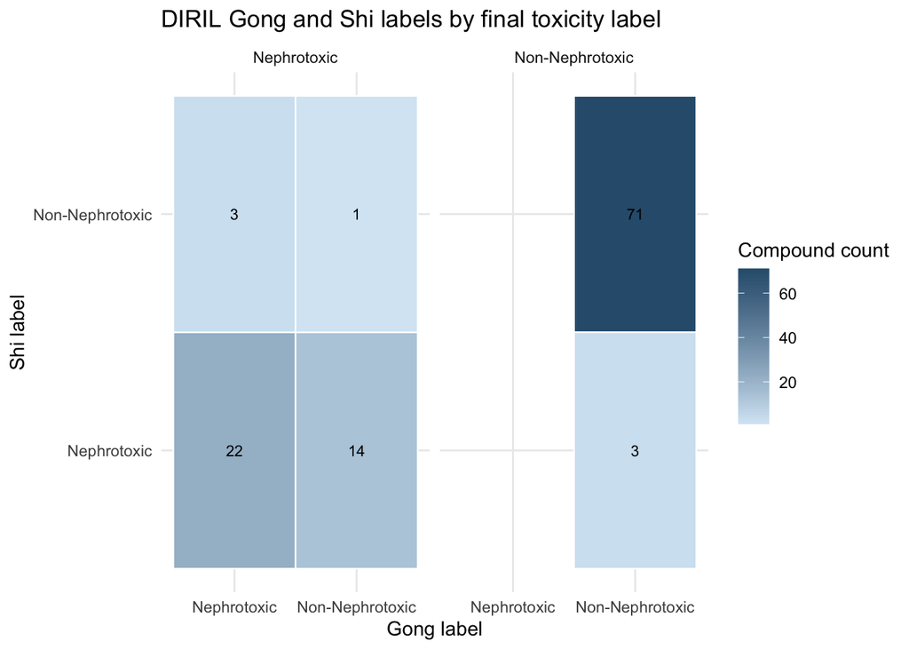

```r
ggplot(diril_consensus, aes(x = Gong, y = Shi, fill = n)) +
  geom_tile(color = "white", linewidth = 0.4) +
  geom_text(aes(label = n), size = 3) +
  facet_wrap(~Final) +
  scale_fill_gradient(low = "#D7E8F5", high = "#2F5D7C") +
  labs(
    title = "DIRIL Gong and Shi labels by final toxicity label",
    x = "Gong label",
    y = "Shi label",
    fill = "Compound count"
  ) +
  theme_minimal()
```